# Predict Bike Sharing Demand with AutoGluon Template

## Project: Predict Bike Sharing Demand with AutoGluon

This notebook is a template with each step that you need to complete for the project.

Please fill in your code where there are explicit `?` markers in the notebook. You are welcome to add more cells and code as you see fit.

Once you have completed all the code implementations, please export your notebook as a HTML file so the reviews can view your code. Make sure you have all outputs correctly outputted.

`File-> Export Notebook As... -> Export Notebook as HTML`

There is a writeup to complete as well after all code implememtation is done. Please answer all questions and attach the necessary tables and charts. You can complete the writeup in either markdown or PDF.

Completing the code template and writeup template will cover all of the rubric points for this project.

The rubric contains "Stand Out Suggestions" for enhancing the project beyond the minimum requirements. The stand out suggestions are optional. If you decide to pursue the "stand out suggestions", you can include the code in this notebook and also discuss the results in the writeup file.

## Step 1: Create an account with Kaggle

### Create Kaggle Account and download API key

Below is example of steps to get the API username and key. Each student will have their own username and key.

1. Open account settings.

2. Scroll down to API and click Create New API Token.

3. Open up `kaggle.json` and use the username and key.


## Step 2: Download the Kaggle dataset using the kaggle python library

### Open up Sagemaker Studio and use starter template

1. Notebook should be using a `ml.t3.medium` instance (2 vCPU + 4 GiB)
2. Notebook should be using kernal: `Python 3 (MXNet 1.8 Python 3.7 CPU Optimized)`

### Install packages

```python
!pip install -U pip
!pip install -U setuptools wheel
!pip install -U "mxnet<2.0.0" bokeh==2.0.1
!pip install autogluon --no-cache-dir
# Without --no-cache-dir, smaller aws instances may have trouble installing
```

[output not shown]

[output cut: 109 more lines]

[output not shown]

### Setup Kaggle API Key

```python
import pandas as pd
import time
```

```python
!pip install --q kaggle
```

```
WARNING: Running pip as the 'root' user can result in broken permissions and conflicting behaviour with the system package manager. It is recommended to use a virtual environment instead: https://pip.pypa.io/warnings/venv
```

```python
!touch ~/.kaggle/kaggle.json
kaggle_api_token = {"username":"arnitpanda","key":"7bf8ecd031d63602078228abfcfbd10f"}
```

```python
import json

# Writes API Credentials to Kaggle file
with open('/root/.kaggle/kaggle.json', 'w') as file:
    json.dump(kaggle_api_token,file)
```

```python
!chmod 600 ~/.kaggle/kaggle.json
```

```python
# # create the .kaggle directory and an empty kaggle.json file
# !mkdir -p /root/.kaggle
# !touch /root/.kaggle/kaggle.json
# !chmod 600 /root/.kaggle/kaggle.json
```

```python
# # Fill in your user name and key from creating the kaggle account and API token file
# import json
# kaggle_username = "arnitpanda"
# kaggle_key = "7bf8ecd031d63602078228abfcfbd10f"

# # Save API token the kaggle.json file
# with open("/root/.kaggle/kaggle.json", "w") as f:
#     f.write(json.dumps({"username": kaggle_username, "key": kaggle_key}))
```

### Download and explore dataset

### Go to the [bike sharing demand competition](https://www.kaggle.com/c/bike-sharing-demand) and agree to the terms

```python
# Download the dataset, it will be in a .zip file so you'll need to unzip it as well.
!kaggle competitions download -c bike-sharing-demand --force
# If you already downloaded it you can use the -o command to overwrite the file
!unzip -o bike-sharing-demand.zip
```

```
Downloading bike-sharing-demand.zip to /root/nd009t-c1-intro-to-ml-project-starter
Archive:  bike-sharing-demand.zip
  inflating: sampleSubmission.csv
  inflating: test.csv
  inflating: train.csv
```

```python
import pandas as pd
import numpy as np
import matplotlib.pyplot as plt
import seaborn as sns
from autogluon.tabular import TabularPredictor
%matplotlib inline
```

```python
# Create the train dataset in pandas by reading the csv
# Set the parsing of the datetime column so you can use some of the `dt` features in pandas later
train = pd.read_csv("train.csv")
train.head()
```

|  | datetime | season | holiday | workingday | weather | temp | atemp | humidity | windspeed | casual | registered | count |
| --- | --- | --- | --- | --- | --- | --- | --- | --- | --- | --- | --- | --- |
| 0 | 2011-01-01 00:00:00 | 1 | 0 | 0 | 1 | 9.84 | 14.395 | 81 | 0.0 | 3 | 13 | 16 |
| 1 | 2011-01-01 01:00:00 | 1 | 0 | 0 | 1 | 9.02 | 13.635 | 80 | 0.0 | 8 | 32 | 40 |
| 2 | 2011-01-01 02:00:00 | 1 | 0 | 0 | 1 | 9.02 | 13.635 | 80 | 0.0 | 5 | 27 | 32 |
| 3 | 2011-01-01 03:00:00 | 1 | 0 | 0 | 1 | 9.84 | 14.395 | 75 | 0.0 | 3 | 10 | 13 |
| 4 | 2011-01-01 04:00:00 | 1 | 0 | 0 | 1 | 9.84 | 14.395 | 75 | 0.0 | 0 | 1 | 1 |

```python
# Simple output of the train dataset to view some of the min/max/varition of the dataset features.
train.describe()
```

|  | season | holiday | workingday | weather | temp | atemp | humidity | windspeed | casual | registered | count |
| --- | --- | --- | --- | --- | --- | --- | --- | --- | --- | --- | --- |
| count | 10886.000000 | 10886.000000 | 10886.000000 | 10886.000000 | 10886.00000 | 10886.000000 | 10886.000000 | 10886.000000 | 10886.000000 | 10886.000000 | 10886.000000 |
| mean | 2.506614 | 0.028569 | 0.680875 | 1.418427 | 20.23086 | 23.655084 | 61.886460 | 12.799395 | 36.021955 | 155.552177 | 191.574132 |
| std | 1.116174 | 0.166599 | 0.466159 | 0.633839 | 7.79159 | 8.474601 | 19.245033 | 8.164537 | 49.960477 | 151.039033 | 181.144454 |
| min | 1.000000 | 0.000000 | 0.000000 | 1.000000 | 0.82000 | 0.760000 | 0.000000 | 0.000000 | 0.000000 | 0.000000 | 1.000000 |
| 25% | 2.000000 | 0.000000 | 0.000000 | 1.000000 | 13.94000 | 16.665000 | 47.000000 | 7.001500 | 4.000000 | 36.000000 | 42.000000 |
| 50% | 3.000000 | 0.000000 | 1.000000 | 1.000000 | 20.50000 | 24.240000 | 62.000000 | 12.998000 | 17.000000 | 118.000000 | 145.000000 |
| 75% | 4.000000 | 0.000000 | 1.000000 | 2.000000 | 26.24000 | 31.060000 | 77.000000 | 16.997900 | 49.000000 | 222.000000 | 284.000000 |
| max | 4.000000 | 1.000000 | 1.000000 | 4.000000 | 41.00000 | 45.455000 | 100.000000 | 56.996900 | 367.000000 | 886.000000 | 977.000000 |

```python
# Create the test pandas dataframe in pandas by reading the csv, remember to parse the datetime!
test = pd.read_csv("test.csv")
test.head()
```

|  | datetime | season | holiday | workingday | weather | temp | atemp | humidity | windspeed |
| --- | --- | --- | --- | --- | --- | --- | --- | --- | --- |
| 0 | 2011-01-20 00:00:00 | 1 | 0 | 1 | 1 | 10.66 | 11.365 | 56 | 26.0027 |
| 1 | 2011-01-20 01:00:00 | 1 | 0 | 1 | 1 | 10.66 | 13.635 | 56 | 0.0000 |
| 2 | 2011-01-20 02:00:00 | 1 | 0 | 1 | 1 | 10.66 | 13.635 | 56 | 0.0000 |
| 3 | 2011-01-20 03:00:00 | 1 | 0 | 1 | 1 | 10.66 | 12.880 | 56 | 11.0014 |
| 4 | 2011-01-20 04:00:00 | 1 | 0 | 1 | 1 | 10.66 | 12.880 | 56 | 11.0014 |

```python
# As columns- 'casual' and 'registered' are not in the test data
# So we're dropping it for now
train.drop(['casual', 'registered'], axis=1, inplace=True)
train.head()
```

|  | datetime | season | holiday | workingday | weather | temp | atemp | humidity | windspeed | count |
| --- | --- | --- | --- | --- | --- | --- | --- | --- | --- | --- |
| 0 | 2011-01-01 00:00:00 | 1 | 0 | 0 | 1 | 9.84 | 14.395 | 81 | 0.0 | 16 |
| 1 | 2011-01-01 01:00:00 | 1 | 0 | 0 | 1 | 9.02 | 13.635 | 80 | 0.0 | 40 |
| 2 | 2011-01-01 02:00:00 | 1 | 0 | 0 | 1 | 9.02 | 13.635 | 80 | 0.0 | 32 |
| 3 | 2011-01-01 03:00:00 | 1 | 0 | 0 | 1 | 9.84 | 14.395 | 75 | 0.0 | 13 |
| 4 | 2011-01-01 04:00:00 | 1 | 0 | 0 | 1 | 9.84 | 14.395 | 75 | 0.0 | 1 |

```python
# Same thing as train and test dataset
submission = pd.read_csv("sampleSubmission.csv")
submission.head()
```

|  | datetime | count |
| --- | --- | --- |
| 0 | 2011-01-20 00:00:00 | 0 |
| 1 | 2011-01-20 01:00:00 | 0 |
| 2 | 2011-01-20 02:00:00 | 0 |
| 3 | 2011-01-20 03:00:00 | 0 |
| 4 | 2011-01-20 04:00:00 | 0 |

## Step 3: Train a model using AutoGluon’s Tabular Prediction

Requirements:

- We are predicting `count`, so it is the label we are setting.
- Ignore `casual` and `registered` columns as they are also not present in the test dataset.
- Use the `root_mean_squared_error` as the metric to use for evaluation.
- Set a time limit of 10 minutes (600 seconds).
- Use the preset `best_quality` to focus on creating the best model.

```python
predictor = TabularPredictor(
    label="count", problem_type="regression", eval_metric="root_mean_squared_error"
).fit(
    train_data=train,
    time_limit=600,
    presets="best_quality"
)
```

```
No path specified. Models will be saved in: "AutogluonModels/ag-20230524_103508/"
Presets specified: ['best_quality']
Stack configuration (auto_stack=True): num_stack_levels=1, num_bag_folds=8, num_bag_sets=20
Beginning AutoGluon training ... Time limit = 600s
AutoGluon will save models to "AutogluonModels/ag-20230524_103508/"
AutoGluon Version:  0.6.2
Python Version:     3.7.10
Operating System:   Linux
Platform Machine:   x86_64
Platform Version:   #1 SMP Tue Apr 25 15:24:19 UTC 2023
Train Data Rows:    10886
Train Data Columns: 9
Label Column: count
Preprocessing data ...
Using Feature Generators to preprocess the data ...
Fitting AutoMLPipelineFeatureGenerator...
	Available Memory:                    2998.92 MB
	Train Data (Original)  Memory Usage: 1.52 MB (0.1% of available memory)
	Inferring data type of each feature based on column values. Set feature_metadata_in to manually specify special dtypes of the features.
	Stage 1 Generators:
		Fitting AsTypeFeatureGenerator...
			Note: Converting 2 features to boolean dtype as they only contain 2 unique values.
	Stage 2 Generators:
		Fitting FillNaFeatureGenerator...
	Stage 3 Generators:
		Fitting IdentityFeatureGenerator...
		Fitting DatetimeFeatureGenerator...
	Stage 4 Generators:
		Fitting DropUniqueFeatureGenerator...
	Types of features in original data (raw dtype, special dtypes):
		('float', [])                      : 3 | ['temp', 'atemp', 'windspeed']
		('int', [])                        : 5 | ['season', 'holiday', 'workingday', 'weather', 'humidity']
		('object', ['datetime_as_object']) : 1 | ['datetime']
	Types of features in processed data (raw dtype, special dtypes):
		('float', [])                : 3 | ['temp', 'atemp', 'windspeed']
		('int', [])                  : 3 | ['season', 'weather', 'humidity']
		('int', ['bool'])            : 2 | ['holiday', 'workingday']
		('int', ['datetime_as_int']) : 5 | ['datetime', 'datetime.year', 'datetime.month', 'datetime.day', 'datetime.dayofweek']
	0.5s = Fit runtime
	9 features in original data used to generate 13 features in processed data.
```

[output cut: 60 more lines]

```
	-53.4261	 = Validation score   (-root_mean_squared_error)
	27.62s	 = Training   runtime
	0.6s	 = Validation runtime
Fitting model: CatBoost_BAG_L2 ... Training model for up to 59.43s of the 59.4s of remaining time.
	Fitting 8 child models (S1F1 - S1F8) | Fitting with ParallelLocalFoldFittingStrategy
	-55.721	 = Validation score   (-root_mean_squared_error)
	59.56s	 = Training   runtime
	0.05s	 = Validation runtime
Completed 1/20 k-fold bagging repeats ...
Fitting model: WeightedEnsemble_L3 ... Training model for up to 360.0s of the -4.35s of remaining time.
	-53.0956	 = Validation score   (-root_mean_squared_error)
	0.28s	 = Training   runtime
	0.0s	 = Validation runtime
AutoGluon training complete, total runtime = 604.84s ... Best model: "WeightedEnsemble_L3"
TabularPredictor saved. To load, use: predictor = TabularPredictor.load("AutogluonModels/ag-20230524_103508/")
```

### Review AutoGluon's training run with ranking of models that did the best.

```python
predictor.fit_summary()
```

```
*** Summary of fit() ***
Estimated performance of each model:
                     model   score_val  pred_time_val    fit_time  pred_time_val_marginal  fit_time_marginal  stack_level  can_infer  fit_order
0      WeightedEnsemble_L3  -53.095560      16.588745  551.567385                0.000885           0.280247            3       True         14
1   RandomForestMSE_BAG_L2  -53.426054      11.804905  412.862876                0.595908          27.620542            2       True         12
2          LightGBM_BAG_L2  -55.109026      11.437346  409.228693                0.228349          23.986360            2       True         11
3          CatBoost_BAG_L2  -55.721005      11.261958  444.806215                0.052960          59.563881            2       True         13
4        LightGBMXT_BAG_L2  -60.091483      15.710643  440.116355                4.501646          54.874021            2       True         10
5    KNeighborsDist_BAG_L1  -84.125061       0.103719    0.033129                0.103719           0.033129            1       True          2
6      WeightedEnsemble_L2  -84.125061       0.104877    0.560539                0.001158           0.527411            2       True          9
7    KNeighborsUnif_BAG_L1 -101.546199       0.106160    0.036638                0.106160           0.036638            1       True          1
8   RandomForestMSE_BAG_L1 -116.544294       0.543663   10.873049                0.543663          10.873049            1       True          5
9     ExtraTreesMSE_BAG_L1 -124.588053       0.522924    4.944073                0.522924           4.944073            1       True          7
10         CatBoost_BAG_L1 -130.535289       0.082969  199.321841                0.082969         199.321841            1       True          6
11         LightGBM_BAG_L1 -131.054162       1.348077   30.280628                1.348077          30.280628            1       True          4
12       LightGBMXT_BAG_L1 -131.460909       8.060270   66.426416                8.060270          66.426416            1       True          3
13  NeuralNetFastAI_BAG_L1 -138.620935       0.441216   73.326558                0.441216          73.326558            1       True          8
Number of models trained: 14
Types of models trained:
{'StackerEnsembleModel_CatBoost', 'StackerEnsembleModel_LGB', 'StackerEnsembleModel_NNFastAiTabular', 'StackerEnsembleModel_RF', 'WeightedEnsembleModel', 'StackerEnsembleModel_XT', 'StackerEnsembleModel_KNN'}
Bagging used: True  (with 8 folds)
Multi-layer stack-ensembling used: True  (with 3 levels)
Feature Metadata (Processed):
(raw dtype, special dtypes):
('float', [])                : 3 | ['temp', 'atemp', 'windspeed']
('int', [])                  : 3 | ['season', 'weather', 'humidity']
('int', ['bool'])            : 2 | ['holiday', 'workingday']
('int', ['datetime_as_int']) : 5 | ['datetime', 'datetime.year', 'datetime.month', 'datetime.day', 'datetime.dayofweek']
Plot summary of models saved to file: AutogluonModels/ag-20230524_103508/SummaryOfModels.html
*** End of fit() summary ***
```

[output not shown]

[output cut: 126 more lines]

```
     fit_order
 0          14
 1          12
 2          11
 3          13
 4          10
 5           2
 6           9
 7           1
 8           5
 9           7
 10          6
 11          4
 12          3
 13          8  }
```

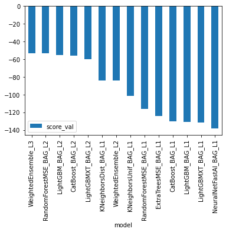

```python
predictor.leaderboard(silent=True).plot(kind="bar", x="model", y="score_val")
```

### Create predictions from test dataset

```python
predictions = predictor.predict(test)
predictions.head()
```

```
0    24.195601
1    42.841290
2    46.029202
3    49.926300
4    52.183033
Name: count, dtype: float32
```

#### NOTE: Kaggle will reject the submission if we don't set everything to be > 0.

```python
# Describe the `predictions` series to see if there are any negative values
predictions.describe()
```

```
count    6493.000000
mean      101.038406
std        90.013916
min         3.000883
25%        20.370081
50%        64.038521
75%       168.123154
max       365.916473
Name: count, dtype: float64
```

```python
# How many negative values do we have?
predictions.lt(0).value_counts()
```

```
False    6493
Name: count, dtype: int64
```

```python
# Set them to zero
predictions.iloc[predictions<0] = 0
predictions.lt(0).value_counts()
```

```
False    6493
Name: count, dtype: int64
```

### Set predictions to submission dataframe, save, and submit

```python
submission["count"] = pd.DataFrame(predictions)
submission.to_csv("submission.csv", index=False)
```

```python
!kaggle competitions submit -c bike-sharing-demand -f submission.csv -m "first raw submission"
```

```
Successfully submitted to Bike Sharing Demand
```

#### View submission via the command line or in the web browser under the competition's page - `My Submissions`

```python
!kaggle competitions submissions -c bike-sharing-demand | tail -n +1 | head -n 6
```

```
fileName                     date                 description                        status    publicScore  privateScore
---------------------------  -------------------  ---------------------------------  --------  -----------  ------------
submission.csv               2023-05-24 10:45:52  first raw submission               complete  1.79438      1.79438
submission.csv               2023-05-24 10:02:42  first raw submission               complete  1.79721      1.79721
submission_new_hpo.csv       2023-05-24 09:30:21  new features with hyperparameters  complete  0.53989      0.53989
submission_new_hpo3.csv      2023-05-24 09:18:57  new features with hyperparameters  complete  0.60299      0.60299
tail: write error: Broken pipe
```

#### Initial score of `1.79438`

## Step 4: Exploratory Data Analysis and Creating an additional feature

- Any additional feature will do, but a great suggestion would be to separate out the datetime into hour, day, or month parts.

```python
# Checking any null values
train.isna().sum()
```

```
datetime      0
season        0
holiday       0
workingday    0
weather       0
temp          0
atemp         0
humidity      0
windspeed     0
count         0
dtype: int64
```

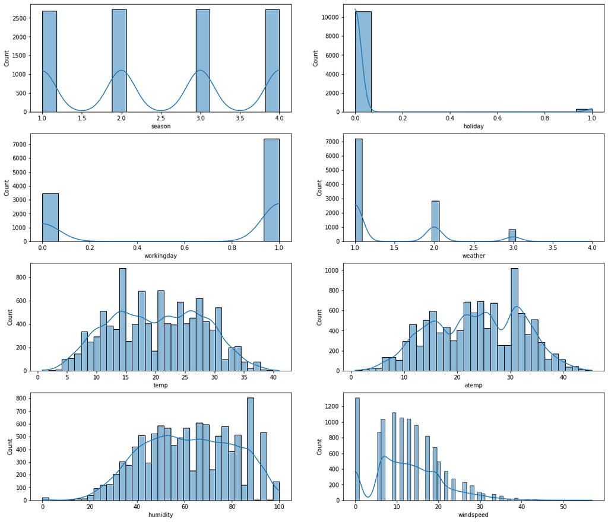

```python
# Create a histogram of all features to show the distribution of each one relative to the data. This is part of the exploritory data analysis
fig, axes = plt.subplots(nrows=4,ncols=2)
fig.set_size_inches(18, 16)
sns.histplot(data=train, x="season", kde=True, ax=axes[0][0])
sns.histplot(data=train, x="holiday", kde=True, ax=axes[0][1])
sns.histplot(data=train, x="workingday", kde=True, ax=axes[1][0])
sns.histplot(data=train, x="weather", kde=True, ax=axes[1][1])
sns.histplot(data=train, x="temp", kde=True, ax=axes[2][0])
sns.histplot(data=train, x="atemp", kde=True, ax=axes[2][1])
sns.histplot(data=train, x="humidity", kde=True, ax=axes[3][0])
sns.histplot(data=train, x="windspeed", kde=True, ax=axes[3][1])
```

```python
# For creating new feature, checking the data-types of all columns
train.dtypes
```

```
datetime       object
season          int64
holiday         int64
workingday      int64
weather         int64
temp          float64
atemp         float64
humidity        int64
windspeed     float64
count           int64
dtype: object
```

```python
test.dtypes
```

```
datetime       object
season          int64
holiday         int64
workingday      int64
weather         int64
temp          float64
atemp         float64
humidity        int64
windspeed     float64
dtype: object
```

```python
# create a new feature: changing the data-type of 'datetime' column

train['datetime']= pd.to_datetime(train['datetime'])
test['datetime']= pd.to_datetime(test['datetime'])
```

```python
train['hour'] = train['datetime'].dt.hour
train['day'] = train['datetime'].dt.day
train['month'] = train['datetime'].dt.month
train.drop(columns="datetime", inplace=True)
train.head()
```

|  | season | holiday | workingday | weather | temp | atemp | humidity | windspeed | count | hour | day | month |
| --- | --- | --- | --- | --- | --- | --- | --- | --- | --- | --- | --- | --- |
| 0 | 1 | 0 | 0 | 1 | 9.84 | 14.395 | 81 | 0.0 | 16 | 0 | 1 | 1 |
| 1 | 1 | 0 | 0 | 1 | 9.02 | 13.635 | 80 | 0.0 | 40 | 1 | 1 | 1 |
| 2 | 1 | 0 | 0 | 1 | 9.02 | 13.635 | 80 | 0.0 | 32 | 2 | 1 | 1 |
| 3 | 1 | 0 | 0 | 1 | 9.84 | 14.395 | 75 | 0.0 | 13 | 3 | 1 | 1 |
| 4 | 1 | 0 | 0 | 1 | 9.84 | 14.395 | 75 | 0.0 | 1 | 4 | 1 | 1 |

```python
test['hour'] = test['datetime'].dt.hour
test['day'] = test['datetime'].dt.day
test['month'] = test['datetime'].dt.month
test.drop(columns="datetime", inplace=True)
test.head()
```

|  | season | holiday | workingday | weather | temp | atemp | humidity | windspeed | hour | day | month |
| --- | --- | --- | --- | --- | --- | --- | --- | --- | --- | --- | --- |
| 0 | 1 | 0 | 1 | 1 | 10.66 | 11.365 | 56 | 26.0027 | 0 | 20 | 1 |
| 1 | 1 | 0 | 1 | 1 | 10.66 | 13.635 | 56 | 0.0000 | 1 | 20 | 1 |
| 2 | 1 | 0 | 1 | 1 | 10.66 | 13.635 | 56 | 0.0000 | 2 | 20 | 1 |
| 3 | 1 | 0 | 1 | 1 | 10.66 | 12.880 | 56 | 11.0014 | 3 | 20 | 1 |
| 4 | 1 | 0 | 1 | 1 | 10.66 | 12.880 | 56 | 11.0014 | 4 | 20 | 1 |

## Make category types for these so models know they are not just numbers

- AutoGluon originally sees these as ints, but in reality they are int representations of a category.
- Setting the dtype to category will classify these as categories in AutoGluon.

```python
train["season"] = train["season"].astype('category')
train["weather"] = train["weather"].astype('category')
test["season"] = test["season"].astype('category')
test["weather"] = test["weather"].astype('category')
```

```python
# View are new feature
train.head()
```

|  | season | holiday | workingday | weather | temp | atemp | humidity | windspeed | count | hour | day | month |
| --- | --- | --- | --- | --- | --- | --- | --- | --- | --- | --- | --- | --- |
| 0 | 1 | 0 | 0 | 1 | 9.84 | 14.395 | 81 | 0.0 | 16 | 0 | 1 | 1 |
| 1 | 1 | 0 | 0 | 1 | 9.02 | 13.635 | 80 | 0.0 | 40 | 1 | 1 | 1 |
| 2 | 1 | 0 | 0 | 1 | 9.02 | 13.635 | 80 | 0.0 | 32 | 2 | 1 | 1 |
| 3 | 1 | 0 | 0 | 1 | 9.84 | 14.395 | 75 | 0.0 | 13 | 3 | 1 | 1 |
| 4 | 1 | 0 | 0 | 1 | 9.84 | 14.395 | 75 | 0.0 | 1 | 4 | 1 | 1 |

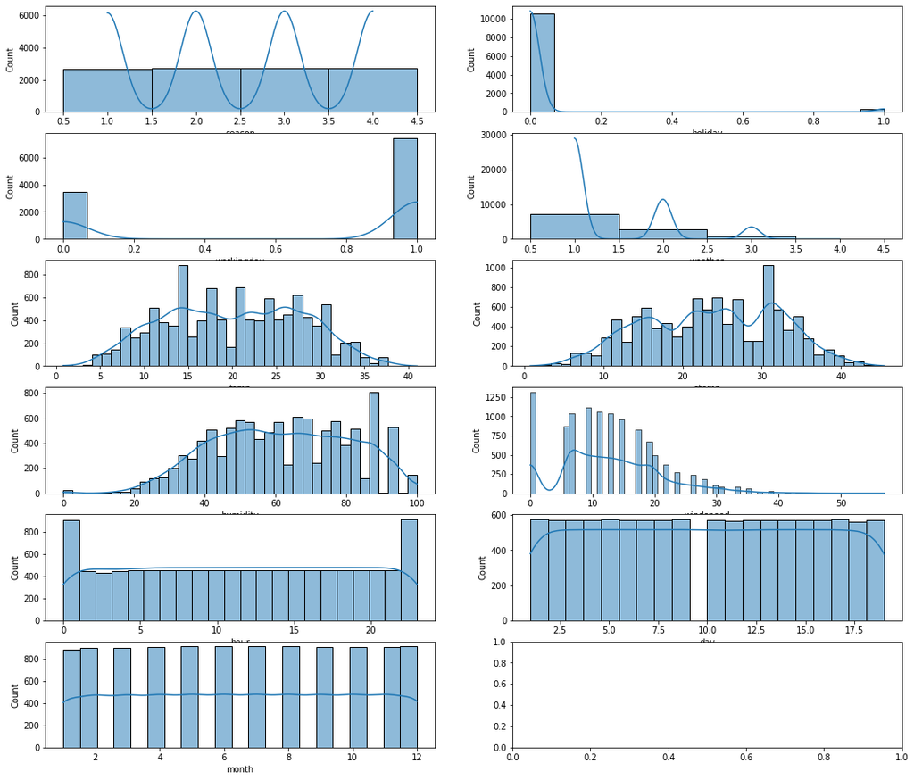

```python
# View histogram of all features again now with the hour feature
fig, axes = plt.subplots(nrows=6,ncols=2)
fig.set_size_inches(18, 16)
sns.histplot(data=train, x="season", kde=True, ax=axes[0][0])
sns.histplot(data=train, x="holiday", kde=True, ax=axes[0][1])
sns.histplot(data=train, x="workingday", kde=True, ax=axes[1][0])
sns.histplot(data=train, x="weather", kde=True, ax=axes[1][1])
sns.histplot(data=train, x="temp", kde=True, ax=axes[2][0])
sns.histplot(data=train, x="atemp", kde=True, ax=axes[2][1])
sns.histplot(data=train, x="humidity", kde=True, ax=axes[3][0])
sns.histplot(data=train, x="windspeed", kde=True, ax=axes[3][1])
sns.histplot(data=train, x="hour", kde=True, ax=axes[4][0])
sns.histplot(data=train, x="day", kde=True, ax=axes[4][1])
sns.histplot(data=train, x="month", kde=True, ax=axes[5][0])
```

## Step 5: Rerun the model with the same settings as before, just with more features

```python
predictor_new_features = TabularPredictor(
    label="count", problem_type="regression", eval_metric="root_mean_squared_error"
).fit(
    train_data=train,
    time_limit=600,
    presets="best_quality"
)
```

```
No path specified. Models will be saved in: "AutogluonModels/ag-20230524_104601/"
Presets specified: ['best_quality']
Stack configuration (auto_stack=True): num_stack_levels=1, num_bag_folds=8, num_bag_sets=20
Beginning AutoGluon training ... Time limit = 600s
AutoGluon will save models to "AutogluonModels/ag-20230524_104601/"
AutoGluon Version:  0.6.2
Python Version:     3.7.10
Operating System:   Linux
Platform Machine:   x86_64
Platform Version:   #1 SMP Tue Apr 25 15:24:19 UTC 2023
Train Data Rows:    10886
Train Data Columns: 11
Label Column: count
Preprocessing data ...
Using Feature Generators to preprocess the data ...
Fitting AutoMLPipelineFeatureGenerator...
	Available Memory:                    2135.94 MB
	Train Data (Original)  Memory Usage: 0.81 MB (0.0% of available memory)
	Inferring data type of each feature based on column values. Set feature_metadata_in to manually specify special dtypes of the features.
	Stage 1 Generators:
		Fitting AsTypeFeatureGenerator...
			Note: Converting 2 features to boolean dtype as they only contain 2 unique values.
	Stage 2 Generators:
		Fitting FillNaFeatureGenerator...
	Stage 3 Generators:
		Fitting IdentityFeatureGenerator...
		Fitting CategoryFeatureGenerator...
			Fitting CategoryMemoryMinimizeFeatureGenerator...
	Stage 4 Generators:
		Fitting DropUniqueFeatureGenerator...
	Types of features in original data (raw dtype, special dtypes):
		('category', []) : 2 | ['season', 'weather']
		('float', [])    : 3 | ['temp', 'atemp', 'windspeed']
		('int', [])      : 6 | ['holiday', 'workingday', 'humidity', 'hour', 'day', ...]
	Types of features in processed data (raw dtype, special dtypes):
		('category', [])  : 2 | ['season', 'weather']
		('float', [])     : 3 | ['temp', 'atemp', 'windspeed']
		('int', [])       : 4 | ['humidity', 'hour', 'day', 'month']
		('int', ['bool']) : 2 | ['holiday', 'workingday']
	0.1s = Fit runtime
```

[output cut: 69 more lines]

```
Fitting model: ExtraTreesMSE_BAG_L2 ... Training model for up to 12.17s of the 12.16s of remaining time.
	-50.3225	 = Validation score   (-root_mean_squared_error)
	7.75s	 = Training   runtime
	0.67s	 = Validation runtime
Fitting model: NeuralNetFastAI_BAG_L2 ... Training model for up to 1.23s of the 1.22s of remaining time.
	Fitting 8 child models (S1F1 - S1F8) | Fitting with ParallelLocalFoldFittingStrategy
	Time limit exceeded... Skipping NeuralNetFastAI_BAG_L2.
2023-05-24 10:56:08,966	ERROR worker.py:400 -- Unhandled error (suppress with 'RAY_IGNORE_UNHANDLED_ERRORS=1'): The worker died unexpectedly while executing this task. Check python-core-worker-*.log files for more information.
Completed 1/20 k-fold bagging repeats ...
Fitting model: WeightedEnsemble_L3 ... Training model for up to 360.0s of the -7.34s of remaining time.
	-49.8683	 = Validation score   (-root_mean_squared_error)
	0.58s	 = Training   runtime
	0.0s	 = Validation runtime
AutoGluon training complete, total runtime = 608.13s ... Best model: "WeightedEnsemble_L3"
TabularPredictor saved. To load, use: predictor = TabularPredictor.load("AutogluonModels/ag-20230524_104601/")
```

```python
predictor_new_features.fit_summary()
```

```
*** Summary of fit() ***
Estimated performance of each model:
                     model   score_val  pred_time_val    fit_time  pred_time_val_marginal  fit_time_marginal  stack_level  can_infer  fit_order
0      WeightedEnsemble_L3  -49.868301      57.105716  493.838007                0.001639           0.583699            3       True         15
1          CatBoost_BAG_L2  -50.181001      55.821687  459.206532                0.115188          63.688325            2       True         13
2     ExtraTreesMSE_BAG_L2  -50.322474      56.371796  403.273090                0.665297           7.754882            2       True         14
3          LightGBM_BAG_L2  -50.894595      55.828001  418.676476                0.121503          23.158268            2       True         11
4   RandomForestMSE_BAG_L2  -50.918480      56.323592  421.811102                0.617094          26.292894            2       True         12
5      WeightedEnsemble_L2  -51.386891      54.024192  356.638401                0.001076           0.511654            2       True          9
6        LightGBMXT_BAG_L2  -52.029842      56.187531  421.420499                0.481032          25.902291            2       True         10
7        LightGBMXT_BAG_L1  -52.705796      44.204551  128.629156               44.204551         128.629156            1       True          3
8          LightGBM_BAG_L1  -53.032741       9.087462   76.191134                9.087462          76.191134            1       True          4
9          CatBoost_BAG_L1  -57.862433       0.141672  141.949623                0.141672         141.949623            1       True          6
10    ExtraTreesMSE_BAG_L1  -63.939702       0.558815    4.958283                0.558815           4.958283            1       True          7
11  RandomForestMSE_BAG_L1  -64.105822       0.589432    9.356833                0.589432           9.356833            1       True          5
12   KNeighborsDist_BAG_L1 -119.365601       0.306127    0.032851                0.306127           0.032851            1       True          2
13   KNeighborsUnif_BAG_L1 -123.933260       0.308643    0.027253                0.308643           0.027253            1       True          1
14  NeuralNetFastAI_BAG_L1 -132.346693       0.509797   34.373073                0.509797          34.373073            1       True          8
Number of models trained: 15
Types of models trained:
{'StackerEnsembleModel_CatBoost', 'StackerEnsembleModel_LGB', 'StackerEnsembleModel_NNFastAiTabular', 'StackerEnsembleModel_RF', 'WeightedEnsembleModel', 'StackerEnsembleModel_XT', 'StackerEnsembleModel_KNN'}
Bagging used: True  (with 8 folds)
Multi-layer stack-ensembling used: True  (with 3 levels)
Feature Metadata (Processed):
(raw dtype, special dtypes):
('category', [])  : 2 | ['season', 'weather']
('float', [])     : 3 | ['temp', 'atemp', 'windspeed']
('int', [])       : 4 | ['humidity', 'hour', 'day', 'month']
('int', ['bool']) : 2 | ['holiday', 'workingday']
Plot summary of models saved to file: AutogluonModels/ag-20230524_104601/SummaryOfModels.html
*** End of fit() summary ***
```

[output not shown]

[output cut: 139 more lines]

```
 0          15
 1          13
 2          14
 3          11
 4          12
 5           9
 6          10
 7           3
 8           4
 9           6
 10          7
 11          5
 12          2
 13          1
 14          8  }
```

```python
predictions_new_features = predictor_new_features.predict(test)
predictions_new_features.head()
```

```
0    28.743317
1     6.342543
2     5.579672
3     4.059424
4     4.240293
Name: count, dtype: float32
```

```python
predictions_new_features.describe()
```

```
count    6493.000000
mean      189.009399
std       165.499115
min         2.488547
25%        48.415260
50%       151.565552
75%       275.621216
max       811.498169
Name: count, dtype: float64
```

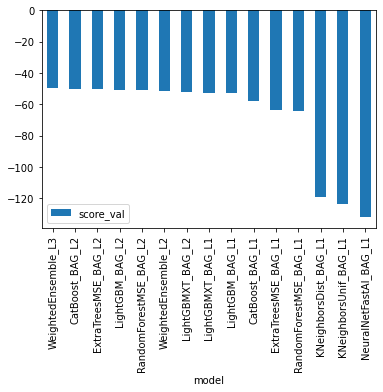

```python
predictor_new_features.leaderboard(silent=True).plot(kind="bar", x="model", y="score_val")
```

```python
# Remember to set all negative values to zero
predictions_new_features.lt(0).value_counts()
```

```
False    6493
Name: count, dtype: int64
```

```python
# Set them to zero
predictions_new_features.iloc[predictions<0] = 0
predictions_new_features.lt(0).value_counts()
```

```
False    6493
Name: count, dtype: int64
```

```python
# Same submitting predictions
submission_new_features = pd.read_csv('./sampleSubmission.csv', parse_dates=["datetime"])
submission_new_features["count"] = predictions_new_features
submission_new_features.to_csv("submission_new_features.csv", index=False)
```

```python
!kaggle competitions submit -c bike-sharing-demand -f submission_new_features.csv -m "new features"
```

```
Successfully submitted to Bike Sharing Demand
```

```python
!kaggle competitions submissions -c bike-sharing-demand | tail -n +1 | head -n 6
```

```
fileName                     date                 description                        status    publicScore  privateScore
---------------------------  -------------------  ---------------------------------  --------  -----------  ------------
submission_new_features.csv  2023-05-24 10:58:25  new features                       complete  0.53813      0.53813
submission.csv               2023-05-24 10:45:52  first raw submission               complete  1.79438      1.79438
submission.csv               2023-05-24 10:02:42  first raw submission               complete  1.79721      1.79721
submission_new_hpo.csv       2023-05-24 09:30:21  new features with hyperparameters  complete  0.53989      0.53989
tail: write error: Broken pipe
```

#### New Score of `0.53813`

## Step 6: Hyper parameter optimization

- There are many options for hyper parameter optimization.
- Options are to change the AutoGluon higher level parameters or the individual model hyperparameters.
- The hyperparameters of the models themselves that are in AutoGluon. Those need the `hyperparameter` and `hyperparameter_tune_kwargs` arguments.

```python
# hpo1
predictor_new_hpo1 = TabularPredictor(
    label="count", problem_type="regression", eval_metric="root_mean_squared_error"
).fit(
    train_data=train,
    time_limit=600,
    presets="best_quality",
    num_bag_folds=5,
    num_bag_sets=5,
    num_stack_levels=2
)
```

```
No path specified. Models will be saved in: "AutogluonModels/ag-20230524_105828/"
Presets specified: ['best_quality']
Stack configuration (auto_stack=True): num_stack_levels=2, num_bag_folds=5, num_bag_sets=5
Beginning AutoGluon training ... Time limit = 600s
AutoGluon will save models to "AutogluonModels/ag-20230524_105828/"
AutoGluon Version:  0.6.2
Python Version:     3.7.10
Operating System:   Linux
Platform Machine:   x86_64
Platform Version:   #1 SMP Tue Apr 25 15:24:19 UTC 2023
Train Data Rows:    10886
Train Data Columns: 11
Label Column: count
Preprocessing data ...
Using Feature Generators to preprocess the data ...
Fitting AutoMLPipelineFeatureGenerator...
	Available Memory:                    2070.49 MB
	Train Data (Original)  Memory Usage: 0.81 MB (0.0% of available memory)
	Inferring data type of each feature based on column values. Set feature_metadata_in to manually specify special dtypes of the features.
	Stage 1 Generators:
		Fitting AsTypeFeatureGenerator...
			Note: Converting 2 features to boolean dtype as they only contain 2 unique values.
	Stage 2 Generators:
		Fitting FillNaFeatureGenerator...
	Stage 3 Generators:
		Fitting IdentityFeatureGenerator...
		Fitting CategoryFeatureGenerator...
			Fitting CategoryMemoryMinimizeFeatureGenerator...
	Stage 4 Generators:
		Fitting DropUniqueFeatureGenerator...
	Types of features in original data (raw dtype, special dtypes):
		('category', []) : 2 | ['season', 'weather']
		('float', [])    : 3 | ['temp', 'atemp', 'windspeed']
		('int', [])      : 6 | ['holiday', 'workingday', 'humidity', 'hour', 'day', ...]
	Types of features in processed data (raw dtype, special dtypes):
		('category', [])  : 2 | ['season', 'weather']
		('float', [])     : 3 | ['temp', 'atemp', 'windspeed']
		('int', [])       : 4 | ['humidity', 'hour', 'day', 'month']
		('int', ['bool']) : 2 | ['holiday', 'workingday']
	0.1s = Fit runtime
```

[output cut: 99 more lines]

```
	Fitting 5 child models (S1F1 - S1F5) | Fitting with ParallelLocalFoldFittingStrategy
	-51.7359	 = Validation score   (-root_mean_squared_error)
	25.05s	 = Training   runtime
	0.07s	 = Validation runtime
Fitting model: ExtraTreesMSE_BAG_L3 ... Training model for up to 5.32s of the 5.3s of remaining time.
	-52.415	 = Validation score   (-root_mean_squared_error)
	7.67s	 = Training   runtime
	0.62s	 = Validation runtime
Completed 1/5 k-fold bagging repeats ...
Fitting model: WeightedEnsemble_L4 ... Training model for up to 360.0s of the -5.62s of remaining time.
	-51.6392	 = Validation score   (-root_mean_squared_error)
	0.65s	 = Training   runtime
	0.0s	 = Validation runtime
AutoGluon training complete, total runtime = 606.49s ... Best model: "WeightedEnsemble_L3"
TabularPredictor saved. To load, use: predictor = TabularPredictor.load("AutogluonModels/ag-20230524_105828/")
```

```python
predictor_new_hpo1.fit_summary()
```

```
*** Summary of fit() ***
Estimated performance of each model:
                     model   score_val  pred_time_val    fit_time  pred_time_val_marginal  fit_time_marginal  stack_level  can_infer  fit_order
0      WeightedEnsemble_L3  -51.040895      71.174914  384.882253                0.000868           0.666262            3       True         16
1      WeightedEnsemble_L4  -51.639195      72.794515  477.386623                0.000849           0.646990            4       True         22
2     ExtraTreesMSE_BAG_L2  -51.703894      70.018222  242.840402                0.631537           7.665663            2       True         13
3   NeuralNetFastAI_BAG_L2  -51.727770      69.803808  314.965436                0.417123          79.790697            2       True         14
4          CatBoost_BAG_L3  -51.735887      72.086857  455.798860                0.066789          25.047989            3       True         20
5          CatBoost_BAG_L2  -51.779459      69.466787  270.334785                0.080102          35.160046            2       True         12
6   RandomForestMSE_BAG_L2  -52.176813      70.045284  261.599585                0.658599          26.424846            2       True         11
7          LightGBM_BAG_L3  -52.354631      72.108810  444.024374                0.088742          13.273503            3       True         18
8           XGBoost_BAG_L2  -52.363594      69.556268  252.349750                0.169583          17.175010            2       True         15
9          LightGBM_BAG_L2  -52.363796      69.492707  249.232815                0.106021          14.058075            2       True         10
10    ExtraTreesMSE_BAG_L3  -52.414970      72.638136  438.418141                0.618068           7.667271            3       True         21
11     WeightedEnsemble_L2  -52.606429      68.503144  158.660691                0.001717           1.609412            2       True          8
12       LightGBMXT_BAG_L3  -52.679766      72.251691  445.347196                0.231623          14.596325            3       True         17
13  RandomForestMSE_BAG_L3  -53.007754      72.647425  456.392657                0.627357          25.641786            3       True         19
14       LightGBMXT_BAG_L2  -53.360327      69.957103  250.476533                0.570418          15.301794            2       True          9
15       LightGBMXT_BAG_L1  -53.885771      51.351346   89.306129               51.351346          89.306129            1       True          3
16         LightGBM_BAG_L1  -54.558276      16.075596   55.893923               16.075596          55.893923            1       True          4
17         CatBoost_BAG_L1  -59.716482       0.098489   73.307744                0.098489          73.307744            1       True          6
18    ExtraTreesMSE_BAG_L1  -63.939702       0.583255    4.752656                0.583255           4.752656            1       True          7
19  RandomForestMSE_BAG_L1  -64.105822       0.869136   11.823319                0.869136          11.823319            1       True          5
20   KNeighborsDist_BAG_L1 -119.365601       0.205350    0.027908                0.205350           0.027908            1       True          2
21   KNeighborsUnif_BAG_L1 -123.933260       0.203514    0.063060                0.203514           0.063060            1       True          1
Number of models trained: 22
Types of models trained:
{'StackerEnsembleModel_CatBoost', 'StackerEnsembleModel_LGB', 'StackerEnsembleModel_XGBoost', 'StackerEnsembleModel_NNFastAiTabular', 'StackerEnsembleModel_RF', 'WeightedEnsembleModel', 'StackerEnsembleModel_XT', 'StackerEnsembleModel_KNN'}
Bagging used: True  (with 5 folds)
Multi-layer stack-ensembling used: True  (with 4 levels)
Feature Metadata (Processed):
(raw dtype, special dtypes):
('category', [])  : 2 | ['season', 'weather']
('float', [])     : 3 | ['temp', 'atemp', 'windspeed']
('int', [])       : 4 | ['humidity', 'hour', 'day', 'month']
('int', ['bool']) : 2 | ['holiday', 'workingday']
Plot summary of models saved to file: AutogluonModels/ag-20230524_105828/SummaryOfModels.html
*** End of fit() summary ***
```

[output not shown]

[output cut: 225 more lines]

```
 7          18
 8          15
 9          10
 10         21
 11          8
 12         17
 13         19
 14          9
 15          3
 16          4
 17          6
 18          7
 19          5
 20          2
 21          1  }
```

```python
predictions_new_hpo1 = predictor_new_hpo1.predict(test)
predictions_new_hpo1.head()
```

```
0    31.976908
1     5.398331
2     4.322267
3     4.124227
4     4.042253
Name: count, dtype: float32
```

```python
predictions_new_hpo1.describe()
```

```
count    6493.000000
mean      187.036118
std       161.775711
min        -3.834882
25%        49.145168
50%       151.464569
75%       273.926086
max       820.284424
Name: count, dtype: float64
```

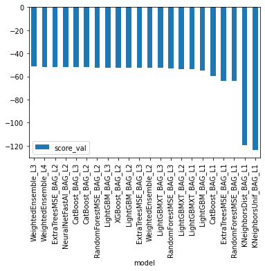

```python
predictor_new_hpo1.leaderboard(silent=True).plot(kind="bar", x="model", y="score_val")
```

```python
# Remember to set all negative values to zero
predictions_new_hpo1.lt(0).value_counts()
```

```
False    6469
True       24
Name: count, dtype: int64
```

```python
# Set them to zero
predictions_new_hpo1.iloc[predictions_new_hpo1<0] = 0
predictions_new_hpo1.lt(0).value_counts()
```

```
False    6493
Name: count, dtype: int64
```

```python
# Same submitting predictions
submission_new_hpo1 = pd.read_csv('./sampleSubmission.csv', parse_dates=["datetime"])
submission_new_hpo1["count"] = predictions_new_hpo1
submission_new_hpo1.to_csv("submission_new_hpo1.csv", index=False)
```

```python
!kaggle competitions submit -c bike-sharing-demand -f submission_new_hpo1.csv -m "new features with hyperparameters"
```

```
Successfully submitted to Bike Sharing Demand
```

```python
!kaggle competitions submissions -c bike-sharing-demand | tail -n +1 | head -n 6
```

```
fileName                     date                 description                        status    publicScore  privateScore
---------------------------  -------------------  ---------------------------------  --------  -----------  ------------
submission_new_hpo1.csv      2023-05-24 11:09:59  new features with hyperparameters  complete  0.55991      0.55991
submission_new_features.csv  2023-05-24 10:58:25  new features                       complete  0.53813      0.53813
submission.csv               2023-05-24 10:45:52  first raw submission               complete  1.79438      1.79438
submission.csv               2023-05-24 10:02:42  first raw submission               complete  1.79721      1.79721
tail: write error: Broken pipe
```

```python
# hpo2
predictor_new_hpo2 = TabularPredictor(
    label="count", problem_type="regression", eval_metric="root_mean_squared_error"
).fit(
    train_data=train,
    time_limit=600,
    presets="best_quality",
    num_bag_folds=5,
    num_bag_sets=10,
    num_stack_levels=2
)
```

[output not shown]

[output cut: 110 more lines]

```
	Fitting 5 child models (S1F1 - S1F5) | Fitting with ParallelLocalFoldFittingStrategy
	-51.8186	 = Validation score   (-root_mean_squared_error)
	25.41s	 = Training   runtime
	0.05s	 = Validation runtime
Fitting model: ExtraTreesMSE_BAG_L3 ... Training model for up to 10.41s of the 10.4s of remaining time.
	-52.0604	 = Validation score   (-root_mean_squared_error)
	7.56s	 = Training   runtime
	0.62s	 = Validation runtime
Completed 1/10 k-fold bagging repeats ...
Fitting model: WeightedEnsemble_L4 ... Training model for up to 360.0s of the -0.87s of remaining time.
	-51.5931	 = Validation score   (-root_mean_squared_error)
	0.97s	 = Training   runtime
	0.0s	 = Validation runtime
AutoGluon training complete, total runtime = 602.14s ... Best model: "WeightedEnsemble_L3"
TabularPredictor saved. To load, use: predictor = TabularPredictor.load("AutogluonModels/ag-20230524_111001/")
```

```python
predictor_new_hpo2.fit_summary()
```

```
*** Summary of fit() ***
Estimated performance of each model:
                     model   score_val  pred_time_val    fit_time  pred_time_val_marginal  fit_time_marginal  stack_level  can_infer  fit_order
0      WeightedEnsemble_L3  -51.074798      54.073514  396.901023                0.000926           0.459547            3       True         16
1      WeightedEnsemble_L4  -51.593111      56.058388  499.885808                0.001050           0.969299            4       True         22
2     ExtraTreesMSE_BAG_L2  -51.685229      52.675000  242.658165                0.606583           7.461069            2       True         13
3   NeuralNetFastAI_BAG_L2  -51.734481      52.468589  311.569666                0.400172          76.372571            2       True         14
4          CatBoost_BAG_L3  -51.818618      54.721139  451.783864                0.046872          25.405399            3       True         20
5          CatBoost_BAG_L2  -51.982387      52.135016  267.010305                0.066598          31.813210            2       True         12
6     ExtraTreesMSE_BAG_L3  -52.060428      55.292646  433.937048                0.618379           7.558583            3       True         21
7   RandomForestMSE_BAG_L2  -52.219326      52.728286  260.534271                0.659869          25.337176            2       True         11
8          LightGBM_BAG_L2  -52.275972      52.174654  249.374720                0.106237          14.177625            2       True         10
9           XGBoost_BAG_L2  -52.357342      52.339367  255.457450                0.270949          20.260354            2       True         15
10         LightGBM_BAG_L3  -52.358347      54.767687  439.089961                0.093420          12.711496            3       True         18
11  RandomForestMSE_BAG_L3  -52.537879      55.298668  453.241030                0.624401          26.862565            3       True         19
12       LightGBMXT_BAG_L3  -52.569464      54.816107  438.860266                0.141840          12.481801            3       True         17
13     WeightedEnsemble_L2  -52.606429      51.075697  146.329147                0.001496           1.121868            2       True          8
14       LightGBMXT_BAG_L2  -53.358857      52.563860  250.956460                0.495442          15.759365            2       True          9
15       LightGBMXT_BAG_L1  -53.885771      43.897289   94.417124               43.897289          94.417124            1       True          3
16         LightGBM_BAG_L1  -54.558276       6.269027   41.194546                6.269027          41.194546            1       True          4
17         CatBoost_BAG_L1  -59.123052       0.101847   85.115080                0.101847          85.115080            1       True          6
18    ExtraTreesMSE_BAG_L1  -63.939702       0.588245    4.843547                0.588245           4.843547            1       True          7
19  RandomForestMSE_BAG_L1  -64.105822       0.601706    9.466143                0.601706           9.466143            1       True          5
20   KNeighborsDist_BAG_L1 -119.365601       0.306180    0.129466                0.306180           0.129466            1       True          2
21   KNeighborsUnif_BAG_L1 -123.933260       0.304124    0.031188                0.304124           0.031188            1       True          1
Number of models trained: 22
Types of models trained:
{'StackerEnsembleModel_CatBoost', 'StackerEnsembleModel_LGB', 'StackerEnsembleModel_XGBoost', 'StackerEnsembleModel_NNFastAiTabular', 'StackerEnsembleModel_RF', 'WeightedEnsembleModel', 'StackerEnsembleModel_XT', 'StackerEnsembleModel_KNN'}
Bagging used: True  (with 5 folds)
Multi-layer stack-ensembling used: True  (with 4 levels)
Feature Metadata (Processed):
(raw dtype, special dtypes):
('category', [])  : 2 | ['season', 'weather']
('float', [])     : 3 | ['temp', 'atemp', 'windspeed']
('int', [])       : 4 | ['humidity', 'hour', 'day', 'month']
('int', ['bool']) : 2 | ['holiday', 'workingday']
Plot summary of models saved to file: AutogluonModels/ag-20230524_111001/SummaryOfModels.html
*** End of fit() summary ***
```

[output not shown]

[output cut: 225 more lines]

```
 7          11
 8          10
 9          15
 10         18
 11         19
 12         17
 13          8
 14          9
 15          3
 16          4
 17          6
 18          7
 19          5
 20          2
 21          1  }
```

```python
predictions_new_hpo2 = predictor_new_hpo2.predict(test)
predictions_new_hpo2.head()
```

```
0    31.897036
1     4.812012
2     3.855205
3     4.143148
4     4.123196
Name: count, dtype: float32
```

```python
predictions_new_hpo2.describe()
```

```
count    6493.000000
mean      187.055374
std       161.622528
min        -7.288372
25%        49.466423
50%       151.792023
75%       273.671783
max       824.801514
Name: count, dtype: float64
```

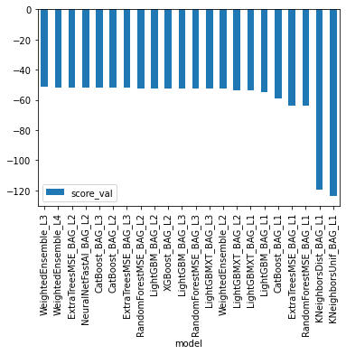

```python
predictor_new_hpo2.leaderboard(silent=True).plot(kind="bar", x="model", y="score_val")
```

```python
# Remember to set all negative values to zero
predictions_new_hpo2.lt(0).value_counts()
```

```
False    6463
True       30
Name: count, dtype: int64
```

```python
# Set them to zero
predictions_new_hpo2.iloc[predictions_new_hpo2<0] = 0
predictions_new_hpo2.lt(0).value_counts()
```

```
False    6493
Name: count, dtype: int64
```

```python
# Same submitting predictions
submission_new_hpo2 = pd.read_csv('./sampleSubmission.csv', parse_dates=["datetime"])
submission_new_hpo2["count"] = predictions_new_hpo2
submission_new_hpo2.to_csv("submission_new_hpo2.csv", index=False)
```

```python
!kaggle competitions submit -c bike-sharing-demand -f submission_new_hpo2.csv -m "new features with hyperparameters"
```

```
Successfully submitted to Bike Sharing Demand
```

```python
!kaggle competitions submissions -c bike-sharing-demand | tail -n +1 | head -n 6
```

```
fileName                     date                 description                        status    publicScore  privateScore
---------------------------  -------------------  ---------------------------------  --------  -----------  ------------
submission_new_hpo2.csv      2023-05-24 11:21:27  new features with hyperparameters  complete  0.56102      0.56102
submission_new_hpo1.csv      2023-05-24 11:09:59  new features with hyperparameters  complete  0.55991      0.55991
submission_new_features.csv  2023-05-24 10:58:25  new features                       complete  0.53813      0.53813
submission.csv               2023-05-24 10:45:52  first raw submission               complete  1.79438      1.79438
tail: write error: Broken pipe
```

```python
# hpo3
predictor_new_hpo3 = TabularPredictor(
    label="count", problem_type="regression", eval_metric="root_mean_squared_error"
).fit(
    train_data=train,
    time_limit=600,
    presets="best_quality",
    num_bag_folds=10,
    num_bag_sets=15,
    num_stack_levels=3
)
```

[output not shown]

[output cut: 92 more lines]

```
	-53.3136	 = Validation score   (-root_mean_squared_error)
	29.14s	 = Training   runtime
	0.24s	 = Validation runtime
Fitting model: LightGBM_BAG_L4 ... Training model for up to 19.14s of the 19.13s of remaining time.
	Fitting 10 child models (S1F1 - S1F10) | Fitting with ParallelLocalFoldFittingStrategy
	-52.6878	 = Validation score   (-root_mean_squared_error)
	26.81s	 = Training   runtime
	0.15s	 = Validation runtime
Completed 1/15 k-fold bagging repeats ...
Fitting model: WeightedEnsemble_L5 ... Training model for up to 360.0s of the -11.9s of remaining time.
	-52.5416	 = Validation score   (-root_mean_squared_error)
	0.19s	 = Training   runtime
	0.0s	 = Validation runtime
AutoGluon training complete, total runtime = 612.29s ... Best model: "WeightedEnsemble_L3"
TabularPredictor saved. To load, use: predictor = TabularPredictor.load("AutogluonModels/ag-20230524_112130/")
```

```python
predictor_new_hpo3.fit_summary()
```

```
*** Summary of fit() ***
Estimated performance of each model:
                     model   score_val  pred_time_val    fit_time  pred_time_val_marginal  fit_time_marginal  stack_level  can_infer  fit_order
0      WeightedEnsemble_L3  -50.736472      51.259286  325.194177                0.001390           0.567678            3       True         11
1          CatBoost_BAG_L2  -50.851933      49.800298  271.205083                0.113534          53.821080            2       True          9
2      WeightedEnsemble_L4  -51.098323      52.511035  453.164870                0.000856           0.295524            4       True         16
3          CatBoost_BAG_L3  -51.135390      51.739736  400.588383                0.106435          46.692018            3       True         15
4      WeightedEnsemble_L2  -51.172131      49.279563  217.625837                0.000843           0.295799            2       True          5
5          LightGBM_BAG_L2  -51.438385      49.826049  244.773228                0.139286          27.389225            2       True          7
6     ExtraTreesMSE_BAG_L2  -51.649911      50.387523  224.136710                0.700759           6.752707            2       True         10
7          LightGBM_BAG_L3  -51.891741      51.772374  383.675502                0.139073          29.779137            3       True         13
8   RandomForestMSE_BAG_L2  -52.182232      50.304317  236.663487                0.617553          19.279484            2       True          8
9        LightGBMXT_BAG_L2  -52.286400      50.062168  246.653869                0.375405          29.269866            2       True          6
10       LightGBMXT_BAG_L3  -52.371034      51.859244  382.165664                0.225943          28.269300            3       True         12
11       LightGBMXT_BAG_L1  -52.371892      44.662474  159.187310               44.662474         159.187310            1       True          3
12  RandomForestMSE_BAG_L3  -52.509821      52.264670  376.398191                0.631370          22.501826            3       True         14
13     WeightedEnsemble_L5  -52.541554      53.122599  537.275859                0.000882           0.185906            5       True         19
14         LightGBM_BAG_L4  -52.687756      52.883329  507.945859                0.147207          26.807214            4       True         18
15         LightGBM_BAG_L1  -52.799330       4.616246   58.142728                4.616246          58.142728            1       True          4
16       LightGBMXT_BAG_L4  -53.313561      52.974509  510.282739                0.238388          29.144094            4       True         17
17   KNeighborsDist_BAG_L1 -119.365601       0.204412    0.028243                0.204412           0.028243            1       True          2
18   KNeighborsUnif_BAG_L1 -123.933260       0.203631    0.025722                0.203631           0.025722            1       True          1
Number of models trained: 19
Types of models trained:
{'StackerEnsembleModel_CatBoost', 'StackerEnsembleModel_LGB', 'StackerEnsembleModel_RF', 'WeightedEnsembleModel', 'StackerEnsembleModel_XT', 'StackerEnsembleModel_KNN'}
Bagging used: True  (with 10 folds)
Multi-layer stack-ensembling used: True  (with 5 levels)
Feature Metadata (Processed):
(raw dtype, special dtypes):
('category', [])  : 2 | ['season', 'weather']
('float', [])     : 3 | ['temp', 'atemp', 'windspeed']
('int', [])       : 4 | ['humidity', 'hour', 'day', 'month']
('int', ['bool']) : 2 | ['holiday', 'workingday']
Plot summary of models saved to file: AutogluonModels/ag-20230524_112130/SummaryOfModels.html
*** End of fit() summary ***
```

[output not shown]

[output cut: 186 more lines]

```
 4           5
 5           7
 6          10
 7          13
 8           8
 9           6
 10         12
 11          3
 12         14
 13         19
 14         18
 15          4
 16         17
 17          2
 18          1  }
```

```python
predictions_new_hpo3 = predictor_new_hpo3.predict(test)
predictions_new_hpo3.head()
```

```
0    46.908680
1     8.975745
2     6.938956
3     5.724129
4     5.980663
Name: count, dtype: float32
```

```python
predictions_new_hpo3.describe()
```

```
count    6493.000000
mean      188.181046
std       164.383102
min         5.149123
25%        48.124512
50%       152.412567
75%       273.898865
max       834.236206
Name: count, dtype: float64
```

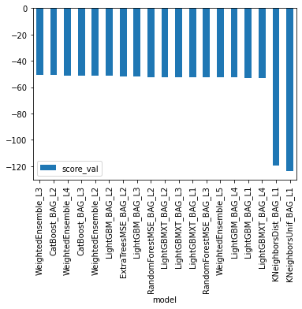

```python
predictor_new_hpo3.leaderboard(silent=True).plot(kind="bar", x="model", y="score_val")
```

```python
# Remember to set all negative values to zero
predictions_new_hpo3.lt(0).value_counts()
```

```
False    6493
Name: count, dtype: int64
```

```python
# Set them to zero
predictions_new_hpo3.iloc[predictions_new_hpo3<0] = 0
predictions_new_hpo3.lt(0).value_counts()
```

```
False    6493
Name: count, dtype: int64
```

```python
# Same submitting predictions
submission_new_hpo3 = pd.read_csv('./sampleSubmission.csv', parse_dates=["datetime"])
submission_new_hpo3["count"] = predictions_new_hpo3
submission_new_hpo3.to_csv("submission_new_hpo3.csv", index=False)
```

```python
!kaggle competitions submit -c bike-sharing-demand -f submission_new_hpo3.csv -m "new features with hyperparameters"
```

```
Successfully submitted to Bike Sharing Demand
```

```python
!kaggle competitions submissions -c bike-sharing-demand | tail -n +1 | head -n 6
```

```
fileName                     date                 description                        status    publicScore  privateScore
---------------------------  -------------------  ---------------------------------  --------  -----------  ------------
submission_new_hpo3.csv      2023-05-24 11:34:06  new features with hyperparameters  complete  0.59972      0.59972
submission_new_hpo2.csv      2023-05-24 11:21:27  new features with hyperparameters  complete  0.56102      0.56102
submission_new_hpo1.csv      2023-05-24 11:09:59  new features with hyperparameters  complete  0.55991      0.55991
submission_new_features.csv  2023-05-24 10:58:25  new features                       complete  0.53813      0.53813
tail: write error: Broken pipe
```

```python
# hpo
predictor_new_hpo = TabularPredictor(
    label="count", problem_type="regression", eval_metric="root_mean_squared_error"
).fit(
    train_data=train,
    time_limit=600,
    presets="best_quality",
    hyperparameter_tune_kwargs='auto'
)
```

```
No model was trained during hyperparameter tuning NeuralNetTorch_BAG_L2... Skipping this model.
Fitting model: LightGBMLarge_BAG_L2 ... Training model for up to 23.08s of the 8.57s of remaining time.
	Fitting 8 child models (S1F1 - S1F8) | Fitting with ParallelLocalFoldFittingStrategy
	-52.2654	 = Validation score   (-root_mean_squared_error)
	34.86s	 = Training   runtime
	0.22s	 = Validation runtime
Completed 1/20 k-fold bagging repeats ...
Fitting model: WeightedEnsemble_L3 ... Training model for up to 360.0s of the -31.57s of remaining time.
	-50.9561	 = Validation score   (-root_mean_squared_error)
	0.66s	 = Training   runtime
	0.0s	 = Validation runtime
AutoGluon training complete, total runtime = 632.42s ... Best model: "WeightedEnsemble_L3"
TabularPredictor saved. To load, use: predictor = TabularPredictor.load("AutogluonModels/ag-20230524_113408/")
```

```python
predictor_new_hpo.fit_summary()
```

```
*** Summary of fit() ***
Estimated performance of each model:
                     model   score_val  pred_time_val    fit_time  pred_time_val_marginal  fit_time_marginal  stack_level  can_infer  fit_order
0      WeightedEnsemble_L3  -50.956107       4.157084  461.645099                0.001230           0.656184            3       True         18
1     ExtraTreesMSE_BAG_L2  -51.304261       3.930556  297.258981                0.000181          11.444887            2       True         15
2       LightGBM_BAG_L2/T1  -51.592614       3.930510  313.715615                0.000136          27.901521            2       True         12
3       CatBoost_BAG_L2/T1  -51.604548       3.930501  319.385491                0.000127          33.571397            2       True         14
4        XGBoost_BAG_L2/T1  -51.742950       3.930502  321.352597                0.000127          35.538502            2       True         16
5   RandomForestMSE_BAG_L2  -51.817476       3.930532  317.675483                0.000157          31.861389            2       True         13
6      WeightedEnsemble_L2  -51.904997       3.930248  181.437132                0.001278           1.015391            2       True         10
7     LightGBMLarge_BAG_L2  -52.265436       4.155127  320.671218                0.224752          34.857124            2       True         17
8     LightGBMXT_BAG_L2/T1  -52.713362       3.930463  314.343732                0.000089          28.529638            2       True         11
9       LightGBM_BAG_L1/T1  -53.149085       0.000133   59.404951                0.000133          59.404951            1       True          4
10    LightGBMLarge_BAG_L1  -53.320098       3.928701   62.510989                3.928701          62.510989            1       True          9
11    LightGBMXT_BAG_L1/T1  -55.160996       0.000136   58.505801                0.000136          58.505801            1       True          3
12       XGBoost_BAG_L1/T1  -56.763760       0.000100   42.614377                0.000100          42.614377            1       True          8
13    ExtraTreesMSE_BAG_L1  -63.939702       0.000670    9.468872                0.000670           9.468872            1       True          7
14  RandomForestMSE_BAG_L1  -64.105822       0.000296   12.739127                0.000296          12.739127            1       True          5
15      CatBoost_BAG_L1/T1  -66.472409       0.000085   39.745781                0.000085          39.745781            1       True          6
16   KNeighborsDist_BAG_L1 -119.365601       0.000121    0.426376                0.000121           0.426376            1       True          2
17   KNeighborsUnif_BAG_L1 -123.933260       0.000133    0.397820                0.000133           0.397820            1       True          1
Number of models trained: 18
Types of models trained:
{'StackerEnsembleModel_CatBoost', 'StackerEnsembleModel_LGB', 'StackerEnsembleModel_XGBoost', 'StackerEnsembleModel_RF', 'WeightedEnsembleModel', 'StackerEnsembleModel_XT', 'StackerEnsembleModel_KNN'}
Bagging used: True  (with 8 folds)
Multi-layer stack-ensembling used: True  (with 3 levels)
Feature Metadata (Processed):
(raw dtype, special dtypes):
('category', [])  : 2 | ['season', 'weather']
('float', [])     : 3 | ['temp', 'atemp', 'windspeed']
('int', [])       : 4 | ['humidity', 'hour', 'day', 'month']
('int', ['bool']) : 2 | ['holiday', 'workingday']
Plot summary of models saved to file: AutogluonModels/ag-20230524_113408/SummaryOfModels.html
*** End of fit() summary ***
```

[output not shown]

[output cut: 175 more lines]

```
 3          14
 4          16
 5          13
 6          10
 7          17
 8          11
 9           4
 10          9
 11          3
 12          8
 13          7
 14          5
 15          6
 16          2
 17          1  }
```

```python
predictions_new_hpo = predictor_new_hpo.predict(test)
predictions_new_hpo.head()
```

```
0    23.246519
1     6.994833
2     6.310999
3     4.768337
4     4.725110
Name: count, dtype: float32
```

```python
predictions_new_hpo.describe()
```

```
count    6493.000000
mean      190.958878
std       166.380920
min         4.134482
25%        50.941090
50%       154.599380
75%       279.323944
max       847.574951
Name: count, dtype: float64
```

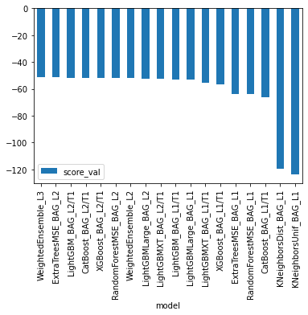

```python
predictor_new_hpo.leaderboard(silent=True).plot(kind="bar", x="model", y="score_val")
```

```python
# Remember to set all negative values to zero
predictions_new_hpo.lt(0).value_counts()
```

```
False    6493
Name: count, dtype: int64
```

```python
# Set them to zero
predictions_new_hpo.iloc[predictions_new_hpo<0] = 0
predictions_new_hpo.lt(0).value_counts()
```

```
False    6493
Name: count, dtype: int64
```

```python
# Same submitting predictions
submission_new_hpo = pd.read_csv('./sampleSubmission.csv', parse_dates=["datetime"])
submission_new_hpo["count"] = predictions_new_hpo
submission_new_hpo.to_csv("submission_new_hpo.csv", index=False)
```

```python
!kaggle competitions submit -c bike-sharing-demand -f submission_new_hpo.csv -m "new features with hyperparameters"
```

```
Successfully submitted to Bike Sharing Demand
```

```python
!kaggle competitions submissions -c bike-sharing-demand | tail -n +1 | head -n 6
```

```
fileName                     date                 description                        status    publicScore  privateScore
---------------------------  -------------------  ---------------------------------  --------  -----------  ------------
submission_new_hpo.csv       2023-05-24 11:45:36  new features with hyperparameters  complete  0.53854      0.53854
submission_new_hpo3.csv      2023-05-24 11:34:06  new features with hyperparameters  complete  0.59972      0.59972
submission_new_hpo2.csv      2023-05-24 11:21:27  new features with hyperparameters  complete  0.56102      0.56102
submission_new_hpo1.csv      2023-05-24 11:09:59  new features with hyperparameters  complete  0.55991      0.55991
tail: write error: Broken pipe
```